# 一、散点图绘制

## 1.传统 plot()

```r
head(mtcars)
```

```
##                    mpg cyl disp  hp drat    wt  qsec vs am gear carb
## Mazda RX4         21.0   6  160 110 3.90 2.620 16.46  0  1    4    4
## Mazda RX4 Wag     21.0   6  160 110 3.90 2.875 17.02  0  1    4    4
## Datsun 710        22.8   4  108  93 3.85 2.320 18.61  1  1    4    1
## Hornet 4 Drive    21.4   6  258 110 3.08 3.215 19.44  1  0    3    1
## Hornet Sportabout 18.7   8  360 175 3.15 3.440 17.02  0  0    3    2
## Valiant           18.1   6  225 105 2.76 3.460 20.22  1  0    3    1
```

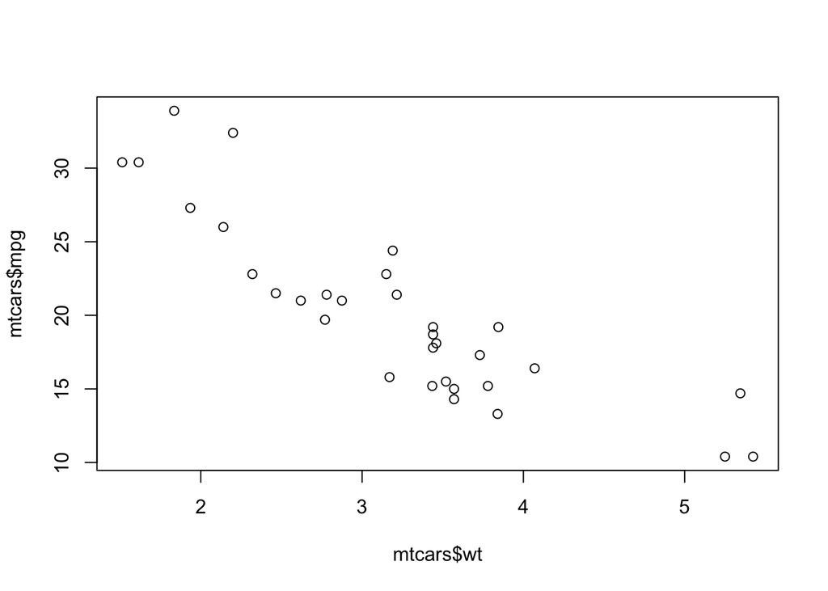

```r
plot(mtcars$wt,mtcars$mpg)
```

> - mpg:耗油量（英里每加仑）
> - cty mpg：城市公路驾驶时的耗油量
> - hwy mpg: 高速公路驾驶时耗油量
> - disp:发动机排量
> - cyl:汽缸数目(cylinders)

## 2.快速绘制 qplot()

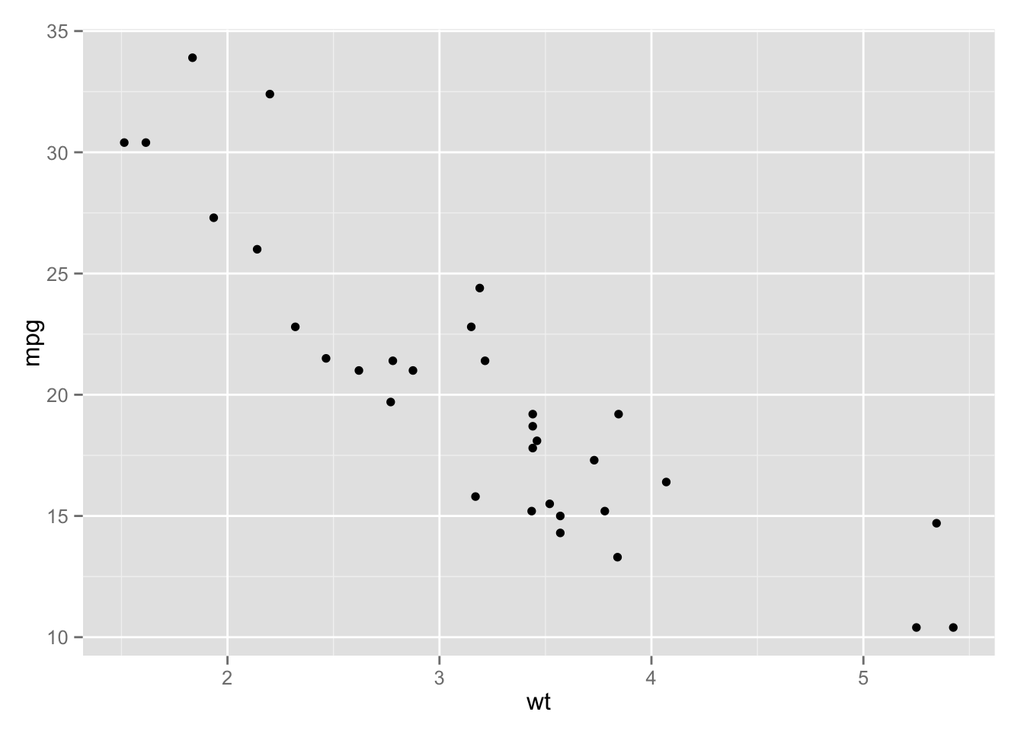

```r
library(ggplot2)
qplot(wt,mpg,data=mtcars)
```

## 3.ggplot()

如果绘图所用的两个参数向量包含在同一个数据框内。

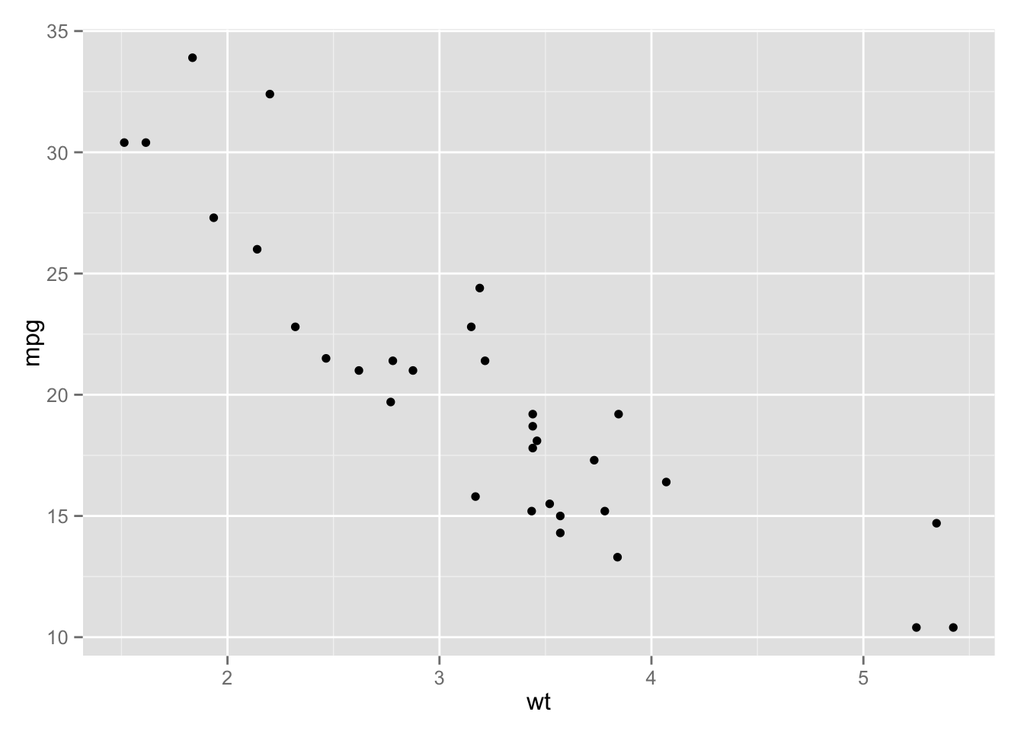

```r
library(ggplot2)
p <- ggplot(mtcars,aes(x=wt,y=mpg))
p + geom_point()
```

### 二、绘制基本散点图

#### 1.运行geom_point()函数，分别映射一个变量到x和y

```r
library(gcookbook)  #为了使用数据
head(heightweight)
```

```
##   sex ageYear ageMonth heightIn weightLb
## 1   f   11.92      143     56.3     85.0
## 2   f   12.92      155     62.3    105.0
## 3   f   12.75      153     63.3    108.0
## 4   f   13.42      161     59.0     92.0
## 5   f   15.92      191     62.5    112.5
## 6   f   14.25      171     62.5    112.0
```

```r
head(heightweight[,c("ageYear","heightIn")])
```

```
##   ageYear heightIn
## 1   11.92     56.3
## 2   12.92     62.3
## 3   12.75     63.3
## 4   13.42     59.0
## 5   15.92     62.5
## 6   14.25     62.5
```

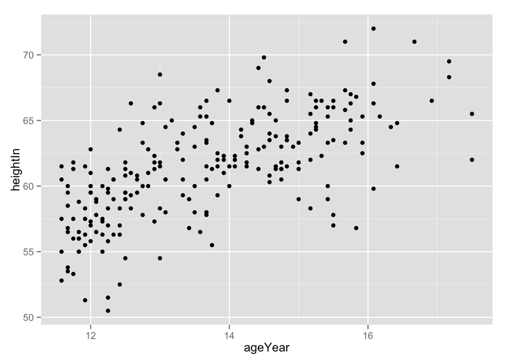

```r
p <- ggplot(heightweight,aes(x=ageYear,y=heightIn))
p + geom_point()
```

> 还可以使用geom_point(size=1.5,shape=21),定义散点的大小和形状

#### 2.使用点形和颜色属性，并基于某变量对数据进行分组

> 通过将变量sex映射给colour或shape，我们可以按变量sex对数据进行分组。

```r
library(gcookbook)
head(heightweight[,c("sex","ageYear","heightIn")])
```

```
##   sex ageYear heightIn
## 1   f   11.92     56.3
## 2   f   12.92     62.3
## 3   f   12.75     63.3
## 4   f   13.42     59.0
## 5   f   15.92     62.5
## 6   f   14.25     62.5
```

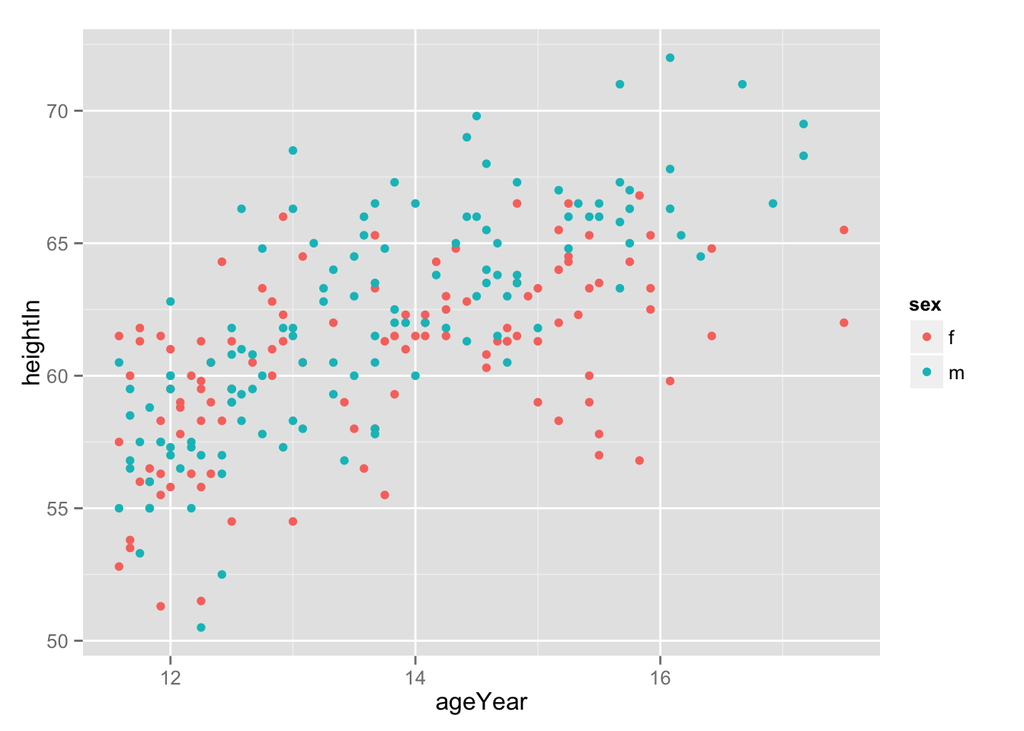

```r
#使用colour属性设置第三个区分参数
ggplot(heightweight,aes(x=ageYear,y=heightIn,colour=sex)) + geom_point()
```

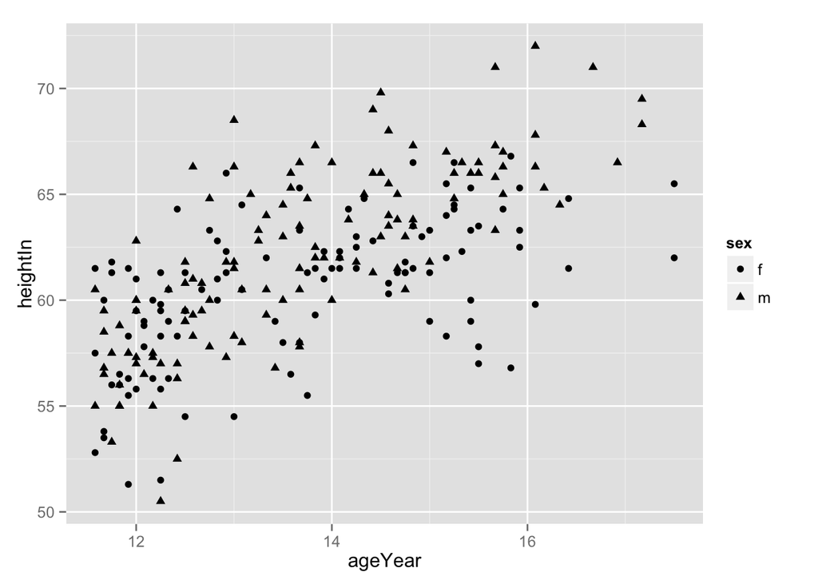

```r
#使用shape属性设置第三个区分参数
ggplot(heightweight,aes(x=ageYear,y=heightIn,shape=sex)) + geom_point()
```

> *分组变量必须是分类变量，换言之，它必须是因子型或者字符型的向量。如果分组变量以数值型变量进行存储，则需要将它转化为因子型变量之后，才能以其作为分组变量。*

可以将一个变量同时映射给shape和colour属性。

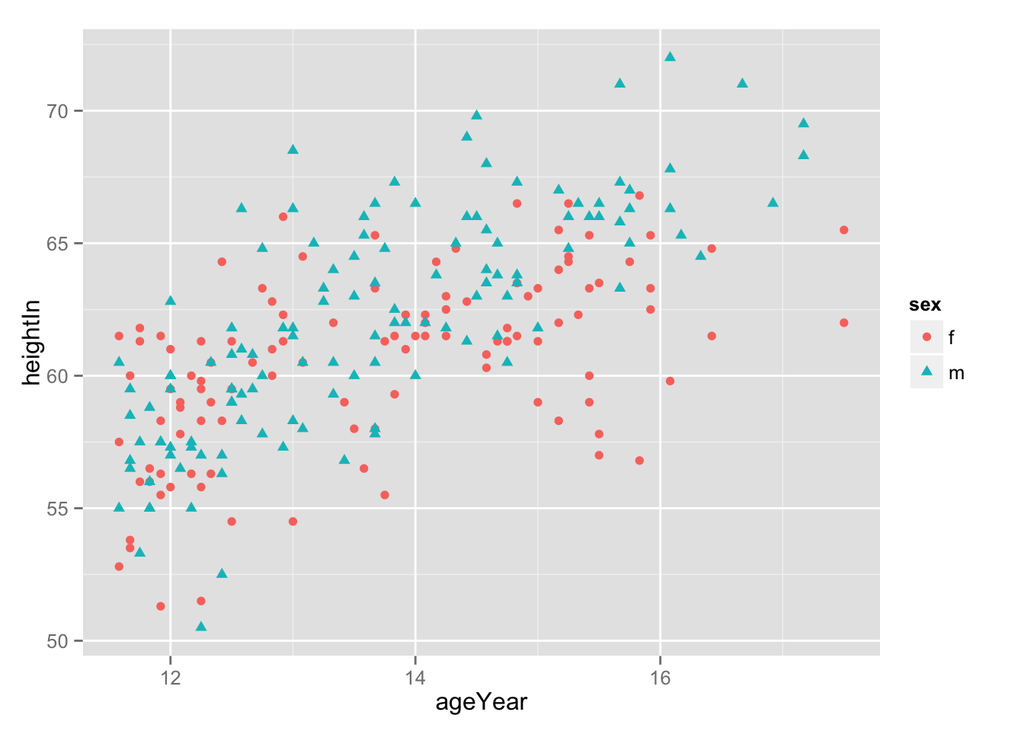

```r
ggplot(heightweight,aes(x=ageYear,y=heightIn,shape=sex,colour=sex))+geom_point()
```

可以通过调用scale_shape_manual()和scale_colour_manual(),scala_colour_brewer()修改

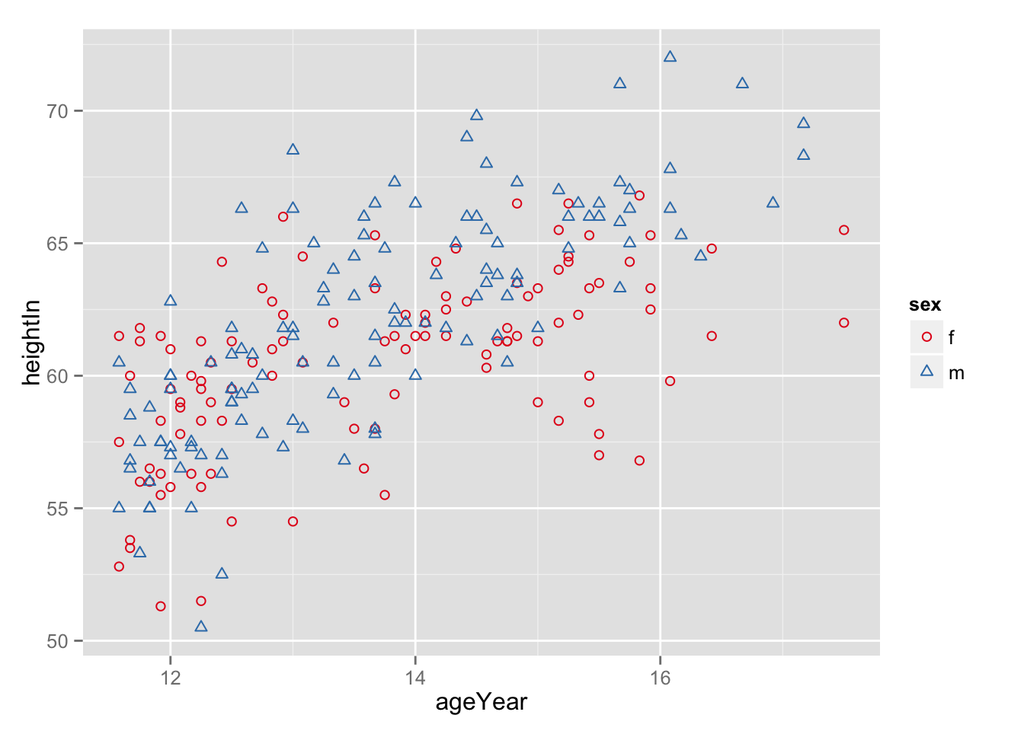

```r
p <- ggplot(heightweight,aes(x=ageYear,y=heightIn,shape=sex,colour=sex))
p+ geom_point() + scale_shape_manual(values=c(1,2)) + scale_colour_brewer(palette="Set1")
```

#### 3.使用不同与默认设置的点形

通过指定geom_point()函数的点形(shape)参数可以设定散点图中所有数据点的点形。

> - 点形1-20的点的颜色，包括实心区域的颜色都可由color参数来控制。对于点形21-25而言，边框线和实心区域的颜色则分别由colour和fill参数来控制。可以用点形和填充色（空心或实心）属性分别表示两个不同的变量。

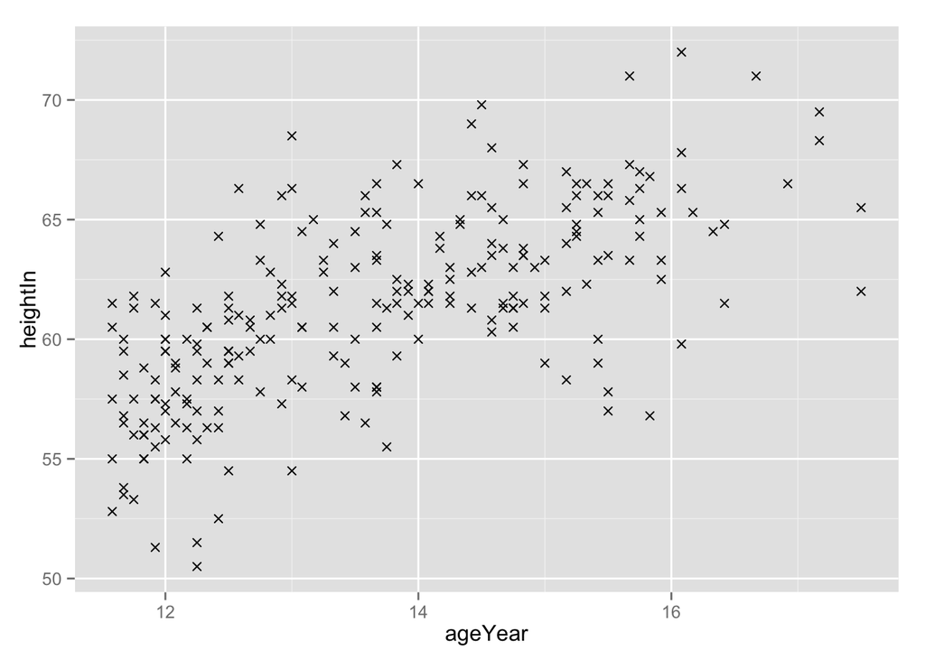

```r
ggplot(heightweight,aes(x=ageYear,y=heightIn)) + geom_point(shape = 4)
```

> 在数据集中增加一个用来标识儿童体重是否超过100磅的列。

```r
hw <- heightweight   #生成一个数据副本
head(hw)
```

```
##   sex ageYear ageMonth heightIn weightLb
## 1   f   11.92      143     56.3     85.0
## 2   f   12.92      155     62.3    105.0
## 3   f   12.75      153     63.3    108.0
## 4   f   13.42      161     59.0     92.0
## 5   f   15.92      191     62.5    112.5
## 6   f   14.25      171     62.5    112.0
```

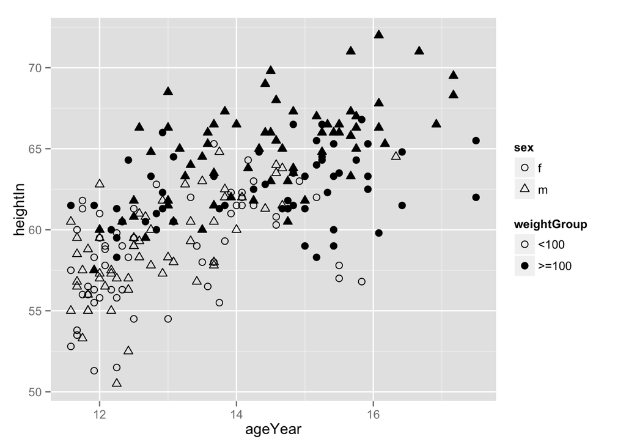

```r
hw$weightGroup <- cut(hw$weightLb,breaks=c(-Inf,100,Inf),labels=c("<100",">=100")) #将数据按照是否大于100磅分为两组
#使用具有颜色和填充色的点形及对应于空值(NA)和填充色的颜色
p <- ggplot(hw,aes(x=ageYear,y=heightIn,shape=sex,fill=weightGroup))
p+geom_point(size=2.5)+scale_shape_manual(values=c(21,24))+scale_fill_manual(values=c(NA,"black"),guide=guide_legend(override.aes=list(shape=21)))
```

> - cut(x,b,labels=FALSE) 该函数需要一个数据向量x和由向量b定义的一组区间，函数将确定x中每个元素落在哪个区间。